# Modelación lineal

## 1.2

*Una buena idea para modelar es el uso de una función suavizadora `smooth()` en modelos lineales aditivos `library(mgcv)`, para lo cual corra un modelo suavizado como:*

*`modesuav<-gam(y~s(X1)+s(X2)+s(X3),family=”gaulss)`*

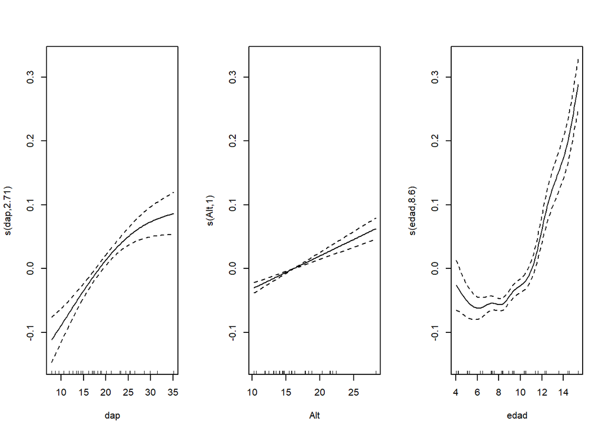

**fig.4** Modelos suavisados

```r
library(mgcv)
modesuav<-with(datos,gam(Vol~s(dap)+s(Alt)+s(edad)))

par(mfrow=c(1,3))
plot(modesuav)
```

## 1.3

*Ejecute un dendromodelo (tree) para ver si aparecen interacciones complejas entre las variables, para lo cual debe bajar la librería tree, incorpórela al R.*

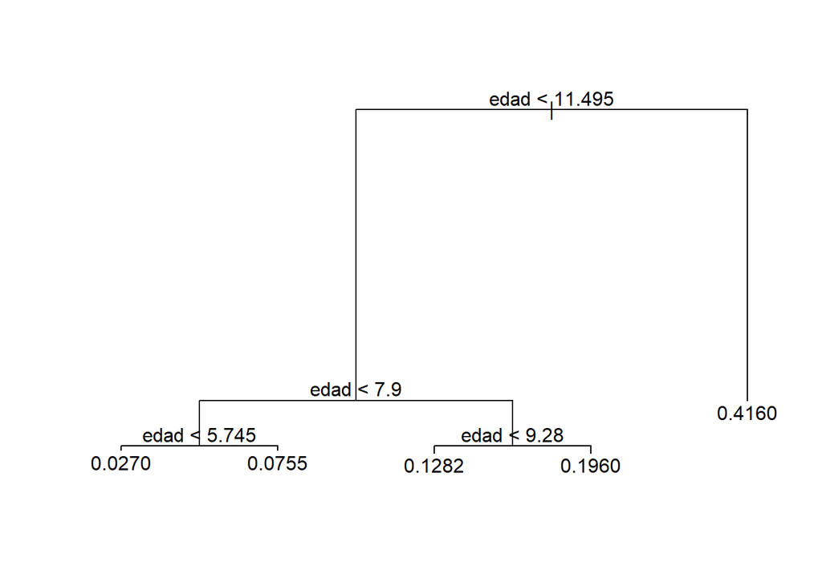

**fig.5**Partición arborea

```r
library(tree)
modarb<-tree(Vol~edad,data=datos)
plot(modarb)
text(modarb)
```

### Modelo

`modelo1<-lm(y~X1*X2*…*Xk+I(X1^2)+I(X2^2)+…..I(Xk^2))`

```r
modelo1<-with(datos, lm(Vol~dap*Alt*edad+I(dap^2)+I(edad^2)+I(Alt^2)) )
summary(modelo1)
```

```
##
## Call:
## lm(formula = Vol ~ dap * Alt * edad + I(dap^2) + I(edad^2) +
##     I(Alt^2))
##
## Residuals:
##       Min        1Q    Median        3Q       Max
## -0.010146 -0.003810 -0.001023  0.003259  0.013295
##
## Coefficients:
##                Estimate Std. Error t value Pr(>|t|)
## (Intercept)   7.058e-02  5.639e-02   1.252    0.224
## dap           8.411e-03  8.822e-03   0.953    0.351
## Alt          -2.378e-03  5.823e-03  -0.408    0.687
## edad         -4.369e-02  2.789e-02  -1.566    0.132
## I(dap^2)     -3.376e-04  7.423e-04  -0.455    0.654
## I(edad^2)    -1.210e-03  5.228e-03  -0.231    0.819
## I(Alt^2)     -5.697e-05  2.334e-04  -0.244    0.809
## dap:Alt      -2.505e-04  8.493e-04  -0.295    0.771
## dap:edad      2.172e-03  3.945e-03   0.551    0.587
## Alt:edad      1.673e-03  2.276e-03   0.735    0.470
## dap:Alt:edad  1.058e-05  1.986e-05   0.533    0.600
##
## Residual standard error: 0.006655 on 22 degrees of freedom
## Multiple R-squared:  0.9986, Adjusted R-squared:  0.998
## F-statistic:  1598 on 10 and 22 DF,  p-value: < 2.2e-16
```

- **fig.1** Resumen del modelo original

```r
modbw<- step( modelo1, direction = "backward", trace=T)
```

```
## Start:  AIC=-322.2
## Vol ~ dap * Alt * edad + I(dap^2) + I(edad^2) + I(Alt^2)
##
##                Df  Sum of Sq        RSS     AIC
## - I(edad^2)     1 2.3729e-06 0.00097678 -324.12
## - I(Alt^2)      1 2.6379e-06 0.00097704 -324.11
## - I(dap^2)      1 9.1604e-06 0.00098356 -323.89
## - dap:Alt:edad  1 1.2563e-05 0.00098696 -323.77
## <none>                       0.00097440 -322.20
##
## Step:  AIC=-324.12
## Vol ~ dap + Alt + edad + I(dap^2) + I(Alt^2) + dap:Alt + dap:edad +
##     Alt:edad + dap:Alt:edad
##
##                Df  Sum of Sq        RSS     AIC
## - I(Alt^2)      1 5.4700e-07 0.00097732 -326.10
## - dap:Alt:edad  1 1.2483e-05 0.00098926 -325.70
## - I(dap^2)      1 3.4369e-05 0.00101114 -324.97
## <none>                       0.00097678 -324.12
##
## Step:  AIC=-326.1
## Vol ~ dap + Alt + edad + I(dap^2) + dap:Alt + dap:edad + Alt:edad +
##     dap:Alt:edad
##
##                Df  Sum of Sq        RSS     AIC
## - dap:Alt:edad  1 1.2499e-05 0.00098982 -327.68
## - I(dap^2)      1 3.5250e-05 0.00101257 -326.93
## <none>                       0.00097732 -326.10
##
## Step:  AIC=-327.68
## Vol ~ dap + Alt + edad + I(dap^2) + dap:Alt + dap:edad + Alt:edad
##
##            Df  Sum of Sq        RSS     AIC
## - dap:Alt   1 0.00000034 0.00099016 -329.67
## <none>                   0.00098982 -327.68
## - I(dap^2)  1 0.00009381 0.00108363 -326.69
## - dap:edad  1 0.00057811 0.00156793 -314.50
## - Alt:edad  1 0.00070345 0.00169327 -311.96
##
## Step:  AIC=-329.67
## Vol ~ dap + Alt + edad + I(dap^2) + dap:edad + Alt:edad
##
##            Df  Sum of Sq       RSS     AIC
## <none>                   0.0009902 -329.67
## - I(dap^2)  1 0.00009619 0.0010864 -328.61
## - dap:edad  1 0.00063181 0.0016220 -315.38
## - Alt:edad  1 0.00312890 0.0041191 -284.63
```

- **fig.2** Posibles modelos

Al terminar de correr el proceso `backward` se puede notar que el modelo quedó de la siguiente forma: `Vol ~ dap + Alt + edad + I(dap^2) + dap:edad + Alt:edad`. Se procedió a corroborar la pertinencia del modelo sin embargo como se puede ver en la **fig.3** no todas las variables del modelo son significativas, se considera la pertinencia de quitar variables del modelo.

```r
modelo2<-with(datos, lm(Vol ~ dap + Alt + edad + I(dap^2) + dap:edad + Alt:edad) )
summary(modelo2)
```

```
##
## Call:
## lm(formula = Vol ~ dap + Alt + edad + I(dap^2) + dap:edad + Alt:edad)
##
## Residuals:
##        Min         1Q     Median         3Q        Max
## -0.0095830 -0.0038943 -0.0009748  0.0031644  0.0126015
##
## Coefficients:
##               Estimate Std. Error t value Pr(>|t|)
## (Intercept)  0.1014926  0.0142912   7.102 1.53e-07 ***
## dap          0.0068768  0.0028166   2.442 0.021738 *
## Alt         -0.0048881  0.0014267  -3.426 0.002045 **
## edad        -0.0467394  0.0069542  -6.721 3.94e-07 ***
## I(dap^2)    -0.0002292  0.0001442  -1.589 0.124081
## dap:edad     0.0015994  0.0003927   4.073 0.000386 ***
## Alt:edad     0.0014255  0.0001573   9.064 1.57e-09 ***
## ---
## Signif. codes:  0 '***' 0.001 '**' 0.01 '*' 0.05 '.' 0.1 ' ' 1
##
## Residual standard error: 0.006171 on 26 degrees of freedom
## Multiple R-squared:  0.9986, Adjusted R-squared:  0.9983
## F-statistic:  3098 on 6 and 26 DF,  p-value: < 2.2e-16
```

- **fig.3** Modelo elegido 1

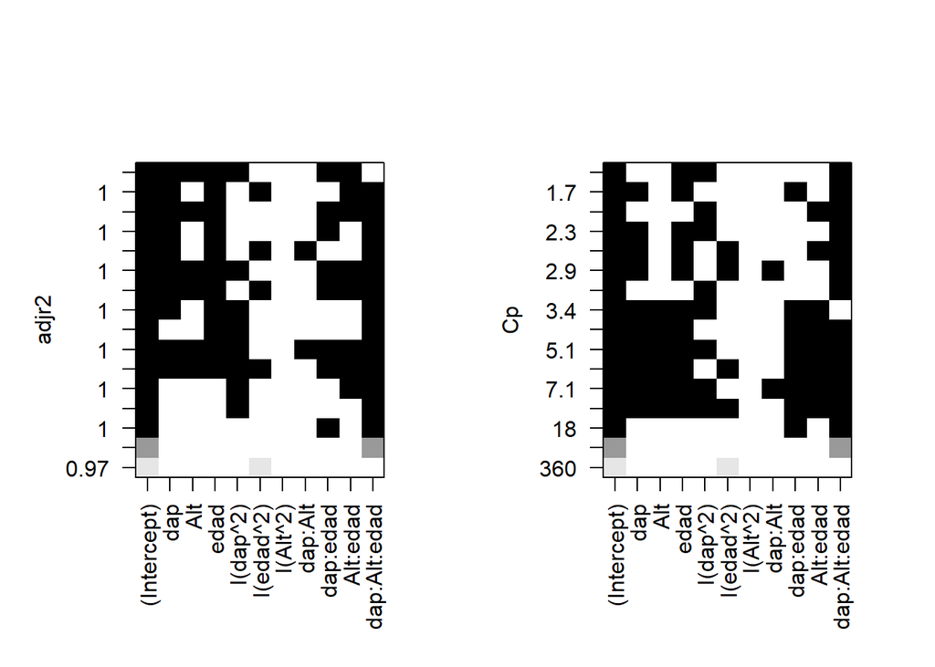

**fig.4** criterios para la elecciòn de variables

```r
library(leaps)

s<- regsubsets(Vol~dap*Alt*edad+I(dap^2)+I(edad^2)+I(Alt^2),
               data = datos, nbest = 2, method=c("exhaustive", "backward", "forward", "seqrep"))

par(mfrow=c(1,2))
plot(s, scale = "adjr2")
plot(s, scale = "Cp")
```

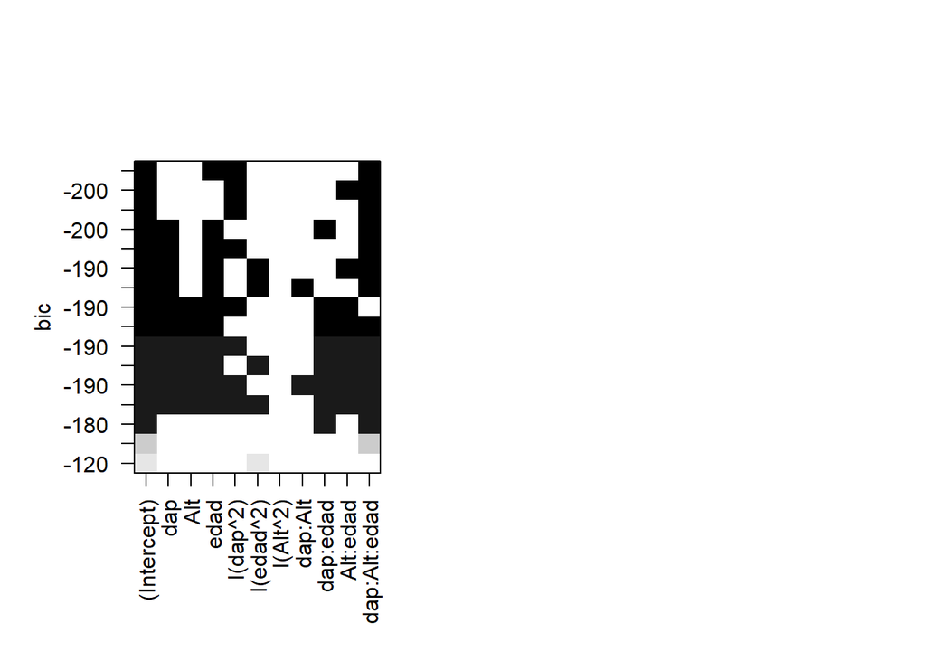

**fig.4** criterios para la elecciòn de variables

```r
plot(s)
```

Al quitar la variable `alt:edad` el modelo es significativo, lo que sería una muestra de la pertinencia de este. Lo que es preciso ahora es hacer pruebas para la viabilidad del modelo, esto se hará en el siguiente apartado.

```r
modelo3<-with(datos, lm(Vol ~ dap + Alt + edad + I(dap^2) + dap:edad ) )
summary(modelo3)
```

```
##
## Call:
## lm(formula = Vol ~ dap + Alt + edad + I(dap^2) + dap:edad)
##
## Residuals:
##        Min         1Q     Median         3Q        Max
## -0.0186431 -0.0101059 -0.0008209  0.0067953  0.0197423
##
## Coefficients:
##               Estimate Std. Error t value Pr(>|t|)
## (Intercept)  0.0107240  0.0204070   0.526    0.604
## dap          0.0219356  0.0045522   4.819 4.96e-05 ***
## Alt          0.0071463  0.0010451   6.838 2.40e-07 ***
## edad        -0.0817110  0.0115800  -7.056 1.38e-07 ***
## I(dap^2)    -0.0012892  0.0001690  -7.628 3.32e-08 ***
## dap:edad     0.0046147  0.0004177  11.049 1.60e-11 ***
## ---
## Signif. codes:  0 '***' 0.001 '**' 0.01 '*' 0.05 '.' 0.1 ' ' 1
##
## Residual standard error: 0.01235 on 27 degrees of freedom
## Multiple R-squared:  0.9942, Adjusted R-squared:  0.9931
## F-statistic: 923.8 on 5 and 27 DF,  p-value: < 2.2e-16
```

## 1.4

**¿Hay heterocedasticidad?**

```r
shapiro.test(rstudent(modelo3))
```

```
##
##  Shapiro-Wilk normality test
##
## data:  rstudent(modelo3)
## W = 0.96654, p-value = 0.391
```

- **fig.1** Normalidad de los residuales

```r
library(lmtest)
bptest(modelo3)
```

```
##
##  studentized Breusch-Pagan test
##
## data:  modelo3
## BP = 6.5594, df = 5, p-value = 0.2555
```

- **fig.2** Prueba de Homogeneidad de variazas

Al hacer pruebas de `shapiro.test()` para normalidad y `bptest()` para homogeneidad, se puede concluir de estas que el los residuales del modelo son normales, ademas, la variaza es constante a lo largo de la muestra.

En la **fig.3** se observa el grafico de residuales.

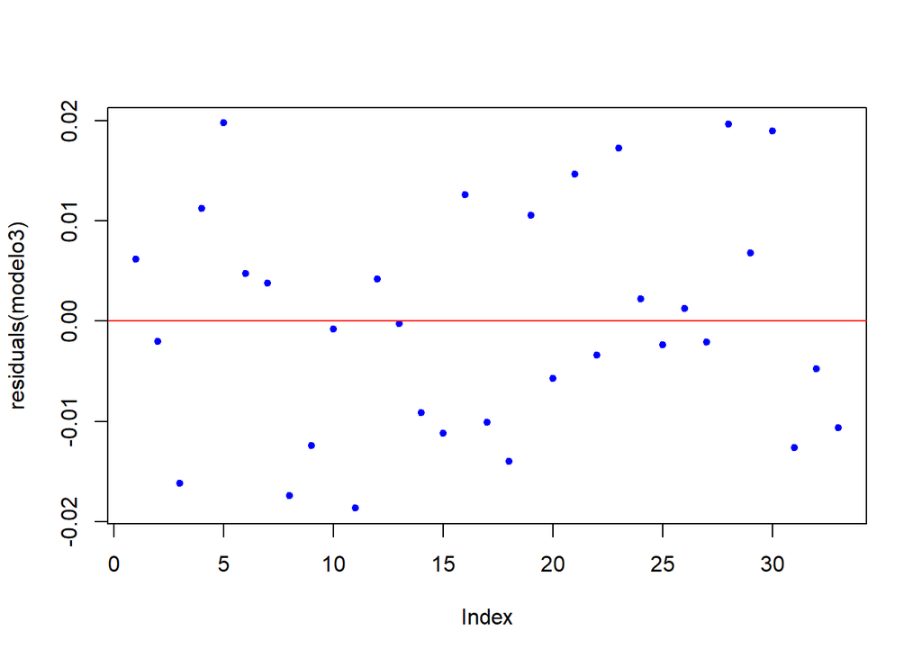

**fig.3** Residuales

```r
plot(residuals(modelo3), pch= 20, col= "blue")
abline(0,0, col= "red")
```

```r
influence.measures(modelo3)
```

[output not shown]

```r
Modeloult3<- with(datos,lm(Vol ~ dap + Alt + edad + I(dap^2) + dap:edad, subset=(1:length(Vol)!= c(5,28))))
anova(Modeloult3)
```

|  | Df | Sum Sq | Mean Sq | F value | Pr(>F) |
| --- | --- | --- | --- | --- | --- |
| dap | 1 | 0.4468463665 | 0.4468463665 | 4372.476700 | 1.361382e-29 |
| Alt | 1 | 0.0237050513 | 0.0237050513 | 231.958436 | 3.716214e-14 |
| edad | 1 | 0.0001704164 | 0.0001704164 | 1.667557 | 2.083989e-01 |
| I(dap^2) | 1 | 0.0194750297 | 0.0194750297 | 190.566870 | 3.371191e-13 |
| dap:edad | 1 | 0.0063604483 | 0.0063604483 | 62.238197 | 3.027724e-08 |
| Residuals | 25 | 0.0025548813 | 0.0001021953 | NA | NA |

- **fig.5** Anova modelo sin observaciones 5 y 28

```r
anova(modelo3)
```

|  | Df | Sum Sq | Mean Sq | F value | Pr(>F) |
| --- | --- | --- | --- | --- | --- |
| dap | 1 | 0.585720946 | 0.5857209460 | 3839.33456 | 1.198182e-30 |
| Alt | 1 | 0.064017395 | 0.0640173953 | 419.62679 | 5.545956e-18 |
| edad | 1 | 0.004689113 | 0.0046891130 | 30.73661 | 7.089521e-06 |
| I(dap^2) | 1 | 0.031609880 | 0.0316098803 | 207.19919 | 3.474665e-14 |
| dap:edad | 1 | 0.018623783 | 0.0186237830 | 122.07679 | 1.602308e-11 |
| Residuals | 27 | 0.004119064 | 0.0001525579 | NA | NA |

- **fig.6** Anova con todas las observaciones

# Punto 2

## 2.1

*Calcule grado de asociación entre las variables `alt` y `dap`, `alt*dap2` y `vol`, `alt` y `vol`, `vol` y la variable combinada . Y califíquelos por lo menos con dos pruebas, y además los intervalos de estimación para los coeficientes de correlación obtenidos.*

```r
summarise(.data = datos,
  cov(dap,Alt), cov(Vol,Alt), cov(dap,Vol),cov(Vol,(dap^2*Alt)))
```

| cov(dap, Alt) | cov(Vol, Alt) | cov(dap, Vol) | cov(Vol, (dap^2 * Alt)) |
| --- | --- | --- | --- |
| 9.755694 | 0.3408108 | 1.045475 | 967.2185 |

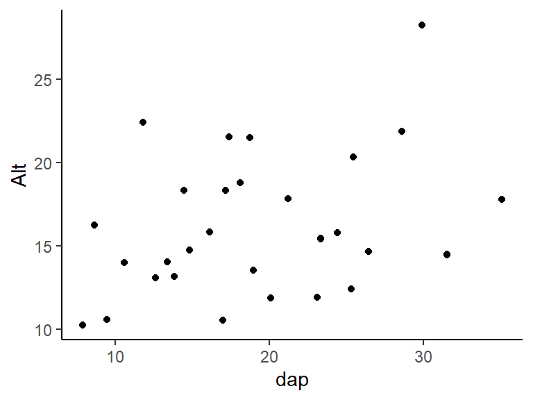

**fig.1**

```r
ggplot(datos, mapping = aes(x = dap, y = Alt))+
  geom_point()+ theme_classic()
```

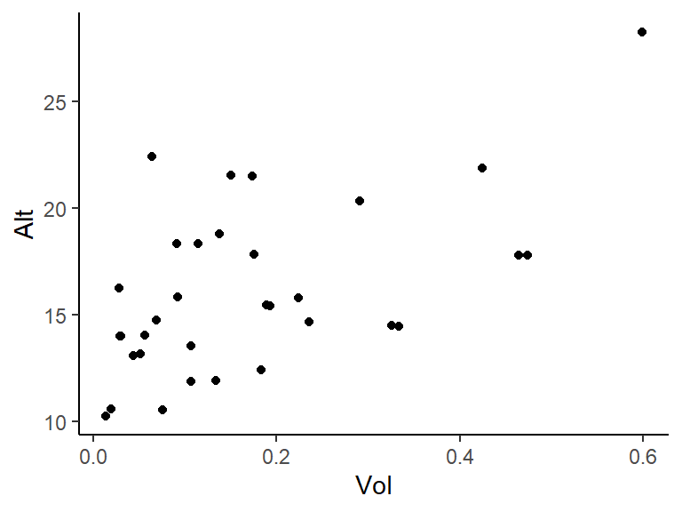

**fig.2**

```r
ggplot(datos, mapping = aes(x = Vol, y = Alt))+
  geom_point()+ theme_classic()
```

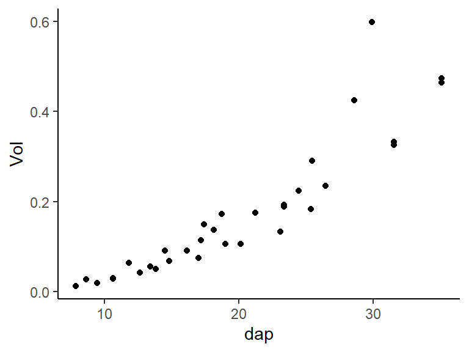

**fig.3**

```r
ggplot(datos, mapping = aes(x = dap, y = Vol))+
  geom_point()+ theme_classic()
```

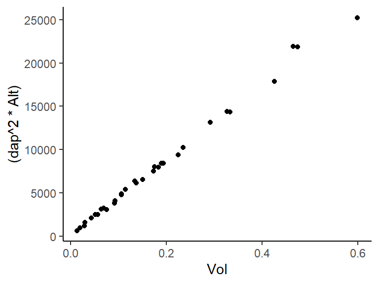

**fig.4**

```r
ggplot(datos, mapping = aes(x = Vol, y = (dap^2*Alt)))+
  geom_point()+ theme_classic()
```

## 2.2

*Usando la prueba de `cor.test(x, y, alternative = c("two.sided", "less", "greater"),method = c("pearson", "kendall", "spearman"),exact = NULL, conf.level = 0.95, continuity = FALSE, ...)` que conclusiones saca de sus resultados anteriores*

```r
with(datos, cor.test(Alt,dap, alternative = c("two.sided", "less", "greater"),method = c("kendall, pearson, spearman"),exact = NULL, conf.level = 0.95, continuity = FALSE))

with(datos, cor.test(Alt,Vol, alternative = c("two.sided", "less", "greater"),method = c("kendall, pearson, spearman"),exact = NULL, conf.level = 0.95, continuity = FALSE))

with(datos, cor.test(Vol,dap, alternative = c("two.sided", "less", "greater"),method = c("kendall, pearson, spearman"),exact = NULL, conf.level = 0.95, continuity = FALSE))

with(datos, cor.test(Vol,(dap^2*Alt), alternative = c("two.sided", "less", "greater"),method = c("kendall, pearson, spearman"),exact = NULL, conf.level = 0.95, continuity = FALSE))
```

[output not shown]

Como la covarianza es difícil de interpretar dado sus múltiples problemas, en la práctica, lo que se hace es trabajar con una corrección de esta, llamada “coeficiente de correlación” el cual tiene varios métodos entre estos: Pearson, Kendall, Spearman. este coeficiente es adimensional, con un rango entre $-1$ y $1$, mostrando que si es mayor a cero, la relación entre las dos variables es directa, si es menor a cero la relación sería inversa, y si es igual o muy cercana a cero podría ocurrir que las variables son independientes o que no existe relación lineal entre ellas.

Luego de esto se parte de dos supuestos, $Ho:$ *dice que las dos variables en estudio son independientes*,mostrando no correlación entre ellas, $Ha$ *dice que las dos variables sí están correlacionadas*;se encontró unas relaciones en `P-values` que se muestran en la tabla, allí podemos evidenciar que las variables que están correlacionadas linealmente y de forma positiva en los tres métodos de correlación trabajados son la `alt vs vol`, el `vol vs dap` y `vol vs alt*dap^2`, el `alt vs dap` no se relaciona linealmente, hay que tener en cuenta que el coeficiente de correlación de `pearson` es paramétrico mientras los otros dos no, pues se basan en rangos, por consiguiente al ser los datos normales es más confiable la prueba de `pearson`, muestra de ello es que los resultados coinciden con los analizados en el punto anterior gráficamente.

[output not shown]

## 2.3

*Ejecute el modelo de regresión lineal `v=b0 + b1*dap + b2*alt + b3*dap*alt+ b4*dap^2*alt` y entregue el modelo minimal y, todos los juicios posibles con base en gráficas y pruebas teóricas de residuales vistas.*

El análisis de regresión consiste en encontrar un modelo que relacione los valores medidos de un conjunto de variables, en este caso, el `dap`, `alt` y sus combinaciones para poder estimar el `vol` de los árboles, se sabe que los valores medidos en el mundo real nunca se ajustan de forma perfecta a un modelo, debido en primer lugar a errores de medida, pero también a que cualquier modelo matemático es una simplificación del mundo real, y si tuviera en cuenta todos los factores que influyen en un conjunto de variables, sería inmanejable. Por tanto, no tiene sentido aspirar a encontrar un modelo que prediga exactamente los valores medidos, y se debe admitir que el modelo cometerá un cierto error. Un modelo útil encuentra una relación funcional sencilla en conjuntos de pocas variables. Se trata de explicar una variable que tiene importancia, en función de otro conjunto de variables mejor conocidas o más fáciles de medir.

```r
mod_vol<-with(datos ,lm(Vol~dap+Alt+(dap*Alt)+I(dap^2*Alt)))
summary(mod_vol)
```

```
##
## Call:
## lm(formula = Vol ~ dap + Alt + (dap * Alt) + I(dap^2 * Alt))
##
## Residuals:
##       Min        1Q    Median        3Q       Max
## -0.020904 -0.004377 -0.001170  0.005899  0.017701
##
## Coefficients:
##                  Estimate Std. Error t value Pr(>|t|)
## (Intercept)     3.246e-02  1.929e-02   1.683  0.10349
## dap            -2.191e-03  8.915e-04  -2.457  0.02045 *
## Alt            -4.173e-03  1.624e-03  -2.570  0.01578 *
## I(dap^2 * Alt)  1.748e-05  1.779e-06   9.824 1.42e-10 ***
## dap:Alt         3.535e-04  1.074e-04   3.292  0.00269 **
## ---
## Signif. codes:  0 '***' 0.001 '**' 0.01 '*' 0.05 '.' 0.1 ' ' 1
##
## Residual standard error: 0.008875 on 28 degrees of freedom
## Multiple R-squared:  0.9969, Adjusted R-squared:  0.9964
## F-statistic:  2243 on 4 and 28 DF,  p-value: < 2.2e-16
```

se encontró con este modelo propuesto que todas las variables independientes para calcular el volumen resultan significativas, sin embargo, la variable combinada `alt*dap^2` es la que más tiene un valor cercano a cero, indicando que esta variable combinada por sí sola mostraría valores estimados para el volumen.

```r
mod_minimizado <- with(datos , lm(Vol~I(dap^2*Alt)))
summary(mod_minimizado)
```

```
##
## Call:
## lm(formula = Vol ~ I(dap^2 * Alt))
##
## Residuals:
##       Min        1Q    Median        3Q       Max
## -0.032654 -0.003769 -0.000041  0.003878  0.026553
##
## Coefficients:
##                  Estimate Std. Error t value Pr(>|t|)
## (Intercept)    -2.606e-03  2.815e-03  -0.926    0.362
## I(dap^2 * Alt)  2.279e-05  2.813e-07  81.027   <2e-16 ***
## ---
## Signif. codes:  0 '***' 0.001 '**' 0.01 '*' 0.05 '.' 0.1 ' ' 1
##
## Residual standard error: 0.01037 on 31 degrees of freedom
## Multiple R-squared:  0.9953, Adjusted R-squared:  0.9951
## F-statistic:  6565 on 1 and 31 DF,  p-value: < 2.2e-16
```

- **Modelo minimizado**

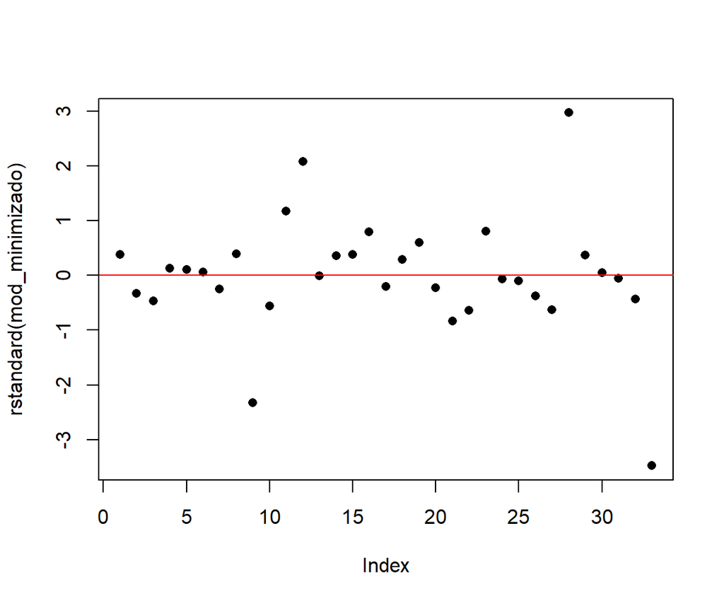

**fig.1** Residuales estanadarizados del modelo minimizado

```r
plot(rstandard(mod_minimizado), pch= 16)
abline(0,0, col= "red")
```

Se realiza un modelo con esta variable, arrojando que es significativo, sin embargo no es normal, ademas, es heterocedástico.

```r
shapiro.test(rstandard(mod_minimizado))
```

```
##
##  Shapiro-Wilk normality test
##
## data:  rstandard(mod_minimizado)
## W = 0.8685, p-value = 0.0008938
```

```r
bptest(mod_minimizado)
```

```
##
##  studentized Breusch-Pagan test
##
## data:  mod_minimizado
## BP = 20.555, df = 1, p-value = 5.794e-06
```

Para resolver este problema, se hace una transformación $log()$ a todo el modelo.

```r
mod_tras <- with(datos , lm(log(Vol)~log(I(dap^2*Alt))))
summary(mod_tras)
```

```
##
## Call:
## lm(formula = log(Vol) ~ log(I(dap^2 * Alt)))
##
## Residuals:
##       Min        1Q    Median        3Q       Max
## -0.130403 -0.029696  0.008462  0.028202  0.135070
##
## Coefficients:
##                      Estimate Std. Error t value Pr(>|t|)
## (Intercept)         -11.05932    0.09279 -119.19   <2e-16 ***
## log(I(dap^2 * Alt))   1.03873    0.01076   96.53   <2e-16 ***
## ---
## Signif. codes:  0 '***' 0.001 '**' 0.01 '*' 0.05 '.' 0.1 ' ' 1
##
## Residual standard error: 0.05698 on 31 degrees of freedom
## Multiple R-squared:  0.9967, Adjusted R-squared:  0.9966
## F-statistic:  9318 on 1 and 31 DF,  p-value: < 2.2e-16
```

Al hacer esto, las pruebas de `breusch pagan` y `shapiro.wilk` arrojan lo esperado, modelo homocedástico y normal.

```r
shapiro.test(rstandard(mod_tras))
```

```
##
##  Shapiro-Wilk normality test
##
## data:  rstandard(mod_tras)
## W = 0.9805, p-value = 0.8014
```

```r
bptest(mod_tras)
```

```
##
##  studentized Breusch-Pagan test
##
## data:  mod_tras
## BP = 2.9738, df = 1, p-value = 0.08462
```

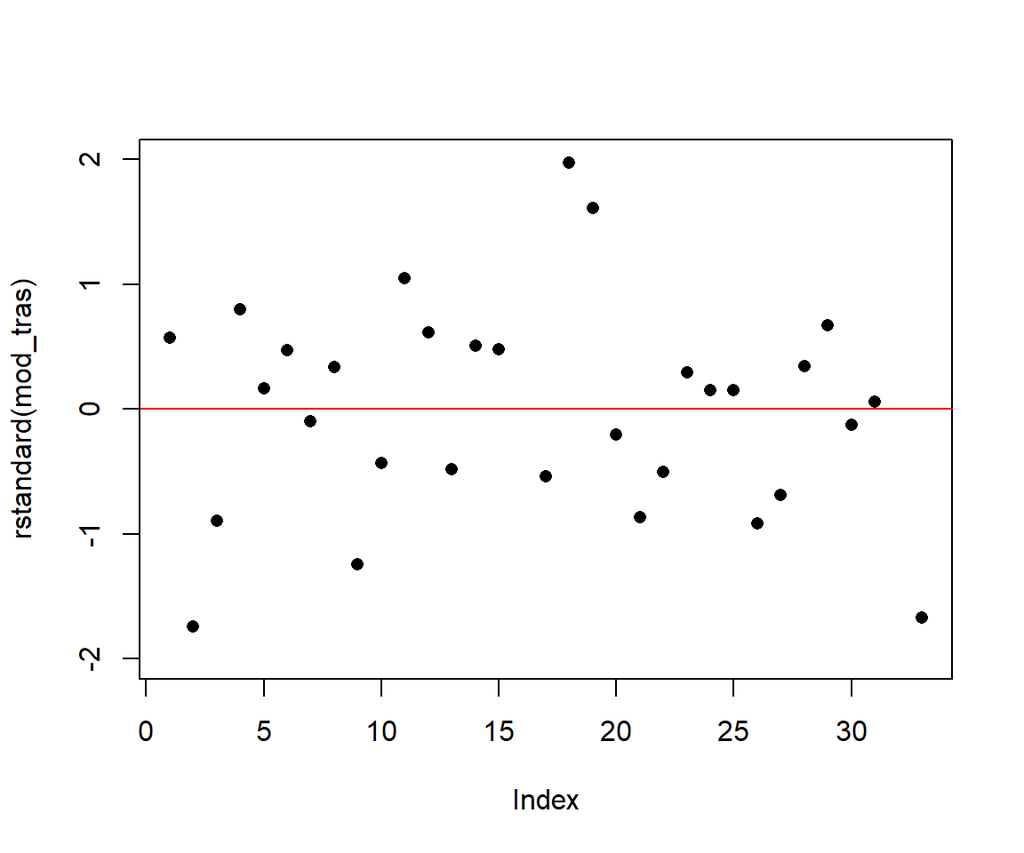

**fig.2** Residuales estanadarizados del modelo minimizado transformado

```r
plot(rstandard(mod_tras), pch= 16, ylim = c(-2,2))
abline(0,0, col= "red")
```

## 2.4

*Proponga y ejecute algunas modelaciones para el factor mórfico:* * *salidas de un volumen con variable combinada* * *salidas de los datos*

```r
datos<- datos %>%  mutate(A.basal= (pi/40000)*dap^2) %>%
  mutate(F.forma= Vol/(A.basal*Alt)) %>%
  mutate(volumen.ff= round(0.2711151*(A.basal*Alt), 3))

datos
```

| dap | Alt | ps | edad | Vol | A.basal | F.forma | volumen.ff |
| --- | --- | --- | --- | --- | --- | --- | --- |
| 18.72 | 21.50 | 1 | 9.33 | 0.173 | 0.027523368 | 0.2923520 | 0.160 |
| 10.61 | 14.00 | 2 | 5.08 | 0.030 | 0.008841392 | 0.2423665 | 0.034 |
| 11.82 | 22.40 | 1 | 6.25 | 0.064 | 0.010972986 | 0.2603797 | 0.067 |
| 13.38 | 14.04 | 2 | 6.46 | 0.056 | 0.014060543 | 0.2836735 | 0.054 |
| 7.88 | 10.27 | 1 | 4.05 | 0.013 | 0.004876883 | 0.2595557 | 0.014 |
| 16.13 | 15.85 | 1 | 7.58 | 0.092 | 0.020434246 | 0.2840534 | 0.088 |
| 18.98 | 13.53 | 2 | 7.30 | 0.106 | 0.028293215 | 0.2769018 | 0.104 |
| 26.42 | 14.68 | 2 | 11.37 | 0.235 | 0.054822080 | 0.2920023 | 0.218 |
| 35.07 | 17.78 | 1 | 14.54 | 0.474 | 0.096596505 | 0.2759848 | 0.466 |
| 21.23 | 17.84 | 1 | 9.41 | 0.175 | 0.035398908 | 0.2771107 | 0.171 |

[output cut: 23 more lines]

```r
summarise(datos, promedio= mean(F.forma))
```

| promedio |
| --- |
| 0.279917 |

En ingeniería forestal tener el dato del factor mórfico es importante ya que con este se puede obtener aproximaciones del volumen de la madera que hay en un bosque, y es mucho más fácil ya que solo se necesita las mediciones del DAP y alturas, esto nos ahorra el trabajo de tener que que tumbar el árbol y cortarlo en trozas para hallar el volumen.

# Punto 3

*Los siguientes datos corresponden a un inventario de Pinus patula, realizado en 4 rodales diferentes en el departamento del Cauca en que: `lote`: código de lote, `parc`: número de la parcela en el mapa, `numarb`: número de árboles medidos/parc, `narha`: numero promedio de árboles/ha, dappr:DAP promedio/parc, `dcpr`: diámetro cuadrmedio/parc, `altpro`: altura total promedia/arbol/parc, `Vtccha`: volumen total con corteza/ha, `Vtscha`: volumen total sin corteza/ha, `vasccha`:volumen aserrío con corteza/ha, `Vpccha`: volumen de pulpa con corteza/ha, `vasescha`: volumen aserrío sin corteza/ha, `vpuscha`: volumen de pulpa sin corteza/ha, `VCSCha`: volumen comercial sin corteza/ha, `porvcvt`: porcentaje de volumen comercial sin corteza con respecto al volumen total.*

## 3.1

Ajuste un modelo para `VCSCha`, con base en `dappr, dcpr, altpro, narha`, para cada uno de los rodales.

```r
rodal<- read.csv2("Inventario.csv", dec = ".")
rodal
```

| lote | parc | numarb | narha | dappr | dcpr | altpro | Vtccha | Vtscha | vasccha | Vpccha | vasescha | vpuscha | VCSCha | porvcvt |
| --- | --- | --- | --- | --- | --- | --- | --- | --- | --- | --- | --- | --- | --- | --- |
| R1 | 169 | 42 | 1680 | 17.40 | 18.52 | 20.03 | 443.69 | 364.59 | 160.68 | 255.34 | 94.72 | 238.76 | 333.48 | 0.75 |
| R1 | 170 | 35 | 1400 | 17.30 | 18.14 | 18.78 | 337.95 | 277.92 | 98.42 | 219.16 | 49.05 | 205.97 | 255.03 | 0.75 |
| R1 | 157 | 39 | 1560 | 13.97 | 14.85 | 17.15 | 236.82 | 195.75 | 49.86 | 159.78 | 24.14 | 139.54 | 163.68 | 0.69 |
| R1 | 160 | 30 | 1200 | 13.79 | 14.16 | 18.34 | 165.92 | 137.66 | 5.11 | 137.53 | 0.00 | 110.74 | 110.74 | 0.67 |
| R1 | 158 | 22 | 880 | 16.86 | 17.51 | 18.56 | 199.82 | 164.45 | 47.72 | 139.14 | 27.69 | 122.32 | 150.01 | 0.75 |
| R1 | 165 | 32 | 1280 | 15.87 | 16.29 | 16.22 | 205.18 | 169.46 | 10.67 | 175.71 | 0.00 | 148.89 | 148.89 | 0.73 |
| R1 | 166 | 30 | 1200 | 13.76 | 14.92 | 16.30 | 177.73 | 146.82 | 23.94 | 132.56 | 11.55 | 113.74 | 125.29 | 0.70 |
| R1 | 163 | 30 | 1200 | 17.11 | 17.93 | 22.15 | 320.60 | 263.87 | 89.04 | 210.35 | 48.00 | 191.48 | 239.47 | 0.75 |
| R1 | 164 | 35 | 1400 | 17.08 | 17.83 | 18.37 | 310.16 | 255.31 | 66.74 | 223.26 | 33.61 | 199.23 | 232.84 | 0.75 |
| R1 | 168 | 36 | 1440 | 16.50 | 17.58 | 16.84 | 298.81 | 245.79 | 98.38 | 179.86 | 59.88 | 163.74 | 223.62 | 0.75 |

[output cut: 47 more lines]

```r
library(tidyverse)
library(modelr)

rodales<- rodal %>%  group_by(lote) %>% nest()


modelos<- function(data){
  lm(VCSCha~dappr + dcpr + altpro + narha, data = data)
}

rodales<- rodales %>%
  mutate(model= map(data, modelos))


model_df<- rodales %>%
  mutate(model_df= map(model, broom::tidy)) %>%
  unnest(model_df, .drop = TRUE)

model_df
```

| lote | term | estimate | std.error | statistic | p.value |
| --- | --- | --- | --- | --- | --- |
| R1 | (Intercept) | -654.1512808 | 47.43719246 | -13.789840 | 9.047321e-06 |
| R1 | dappr | -29.2829884 | 15.91997477 | -1.839387 | 1.154763e-01 |
| R1 | dcpr | 52.8372206 | 15.63120202 | 3.380240 | 1.485339e-02 |
| R1 | altpro | 13.0297712 | 1.53223379 | 8.503775 | 1.447680e-04 |
| R1 | narha | 0.1470130 | 0.01900209 | 7.736677 | 2.448730e-04 |
| R3 | (Intercept) | -477.1584435 | 44.58820241 | -10.701451 | 9.999100e-10 |
| R3 | dappr | -13.9767505 | 11.36542007 | -1.229761 | 2.330574e-01 |
| R3 | dcpr | 32.5510719 | 11.33998729 | 2.870468 | 9.456542e-03 |
| R3 | altpro | 7.2814303 | 2.38019598 | 3.059173 | 6.191621e-03 |
| R3 | narha | 0.1672237 | 0.02285384 | 7.317095 | 4.496572e-07 |

[output cut: 5 more lines]

```r
model_df<- rodales %>%
  mutate(model_df= map(model, broom::glance)) %>%
  unnest(model_df, .drop = TRUE)

model_df
```

| lote | r.squared | adj.r.squared | sigma | statistic | p.value | df | logLik | AIC | BIC | deviance | df.residual |
| --- | --- | --- | --- | --- | --- | --- | --- | --- | --- | --- | --- |
| R1 | 0.9834447 | 0.9724078 | 11.45220 | 89.10537 | 1.792445e-05 | 5 | -39.09458 | 90.18916 | 92.57653 | 786.9179 | 6 |
| R3 | 0.9307693 | 0.9169231 | 18.39903 | 67.22227 | 2.607057e-11 | 5 | -105.49162 | 222.98323 | 230.29649 | 6770.4853 | 20 |
| R4 | 0.9092318 | 0.8865398 | 22.58440 | 40.06830 | 3.812214e-08 | 5 | -92.40485 | 196.80970 | 203.07683 | 8160.8787 | 16 |

En el `R1` hay una alta significancia en el número promedio de $\frac{árboles}{ha}$ `narha` junto con la $altura (total) promedia/árbol/parc$ `altpro`, y una baja significancia en el diámetro cuadrado $\frac{medio}{parc}$ `dcpr`.

En el `R3` se puede observar una alta significancia en el número promedio de $\frac{árboles}{ha}$, y una significancia media en la $altura promedio/árbol/parc$ `altpro` y el $\frac{diámetro cuadrado medio}{parc}$ `dcpr`.

En el `R4` hay una alta significancia en el número promedio de $\frac{árboles}{ha}$ `narha`, junto con el $\frac{diámetro cuadrado medio}{parc}$ `dcpr`, y una significancia media en $\frac{DAP_{promedio}}{parc}$ `dappr` junto con la $altura (total) promedia/árbol/parc$ `altpro`.

## 3.2

Compare los resultados de cada rodal con el modelo general con todos los datos para todo ese bosque.

```r
general<- rodal %>% nest()


modelos<- function(data){
  lm(VCSCha~dappr + dcpr + altpro + narha, data = data)
}

general<- general %>%
  mutate(model= map(data, modelos))

model_g<- general %>%
  mutate(model_g= map(model, broom::tidy)) %>%
  unnest(model_g, .drop = TRUE)

model_g
```

| term | estimate | std.error | statistic | p.value |
| --- | --- | --- | --- | --- |
| (Intercept) | -494.757853 | 29.369162065 | -16.846169 | 1.035463e-22 |
| dappr | -28.242439 | 5.754649947 | -4.907760 | 9.502159e-06 |
| dcpr | 45.439162 | 5.859532577 | 7.754742 | 3.112888e-10 |
| altpro | 10.299718 | 1.521928201 | 6.767545 | 1.161964e-08 |
| narha | 0.143453 | 0.009639312 | 14.882083 | 2.197598e-20 |

```r
model_g<- general %>%
  mutate(model_g= map(model, broom::glance)) %>%
  unnest(model_g, .drop = TRUE)

model_g
```

| r.squared | adj.r.squared | sigma | statistic | p.value | df | logLik | AIC | BIC | deviance | df.residual |
| --- | --- | --- | --- | --- | --- | --- | --- | --- | --- | --- |
| 0.9139684 | 0.9073506 | 19.86901 | 138.1073 | 4.953534e-27 | 5 | -248.6452 | 509.2903 | 521.5486 | 20528.42 | 52 |

También se observa que hay una alta significancia en todos sus componentes (`dappr, decpr, altpro, narha`) esto se puede dar por la relación de los datos, ya que los datos utilizados para el modelo general no son tomados del mismo espacio, por lo tanto pueden existir valores muy diferentes entre rodales.

- **R1 vs modelo general(modg)**

- **R3 vs modg**

En `R3` los residuos del error estándar tienen un valor de $18.4$, aquí se puede observar que los residuos del error estándar de $R3$ tiene un valor mas cercano a los residuos del `modg`. En `R3` solo se encuentra una alta significancia en `narha`, y en el `modg` todos los datos son de ata significancia. El `p-evalue` del `modg` sigue siendo menor al `p-evalue` del `R3` $2.607e^{-11}$.

- **R4 vs modg**

En `R4` los residuos del error estándar es de $22.58$ siendo un valor mayor que los residuos del `modg`. Pero en `R4` se tiene $16$ grados de libertad, y en el `modg` $52$ grados de libertad. En `R4` también solo dos variables son de alta significancia `narha y dcpr` el `p.evalue` de `R4` es de $3.812^{e-08}$ este valor es mayor que el `p-evalue` del `modg`.

## 3.3

```r
mod.nl <- nls(VCSCha~a*dappr*exp(-b*altpro),
              data = rodal, start = list(a=1, b=0))

modg <- lm(VCSCha~dappr + dcpr + altpro + narha, data = rodal)
summary(mod.nl)
```

```
##
## Formula: VCSCha ~ a * dappr * exp(-b * altpro)
##
## Parameters:
##   Estimate Std. Error t value Pr(>|t|)
## a  7.09731    1.81474   3.911 0.000255 ***
## b -0.02184    0.01342  -1.627 0.109387
## ---
## Signif. codes:  0 '***' 0.001 '**' 0.01 '*' 0.05 '.' 0.1 ' ' 1
##
## Residual standard error: 52.87 on 55 degrees of freedom
##
## Number of iterations to convergence: 7
## Achieved convergence tolerance: 4.352e-06
```

```r
shapiro.test(residuals(mod.nl))
```

```
##
##  Shapiro-Wilk normality test
##
## data:  residuals(mod.nl)
## W = 0.95005, p-value = 0.01978
```

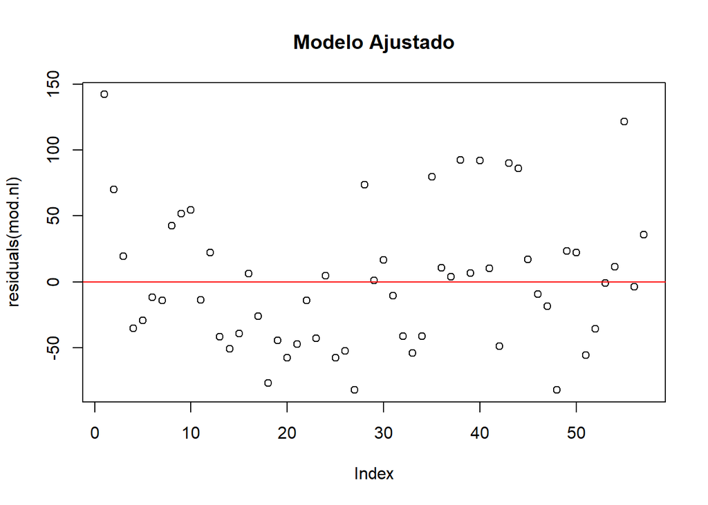

```r
windows()
plot(residuals(mod.nl), main = "Modelo Ajustado")
abline(0,0, col="red")
```

```r
#Prueba de bondad de ajuste
pred <-predict(mod.nl)
chi.mod.nl <- sum((rodal$Vtscha-pred)^2/pred)
chi.mod.nl
```

```
## [1] 1123.852
```

```r
qchisq(0.975, 55)
```

```
## [1] 77.38047
```

```r
pred1 <- predict(modg)
chi.modg <- sum((rodal$Vtscha-pred1)^2/pred1)
chi.modg
```

```
## [1] 532.2127
```

```r
qchisq(0.975, 55)
```

```
## [1] 77.38047
```

```r
#homocedasticidad
AIC(modg, mod.nl)
```

|  | df | AIC |
| --- | --- | --- |
| modg | 6 | 509.2903 |
| mod.nl | 3 | 618.0581 |

Para realizar el modelo ajustado se hizo un modelo no lineal usando la función nls, donde tras varias iteraciones los valores iniciales convergieron a los valores de los parámetros $a=7.098$ y $b=-0.022$.

Para ver que tal se ajustan los modelos, entre los dos modelos el que mejor se ajusta es el modg, pero al comparar el valor del chi cuadrado de cada modelo con el valor tabular se puede ver que estos no son los modelos que mejor se ajustan a los datos. El valor de `AIC` para cada modelo también muestra que el mejor modelo es el `modg`.

En los graficos tambien se pueden observar la homocedasticidad de los datos, ya que estos no varían mucho respecto a la media.

# Punto 4

## 4.1

*Compare dasométricamente los modelos `v=f(dap) y v=f(dap,alt)`*

```r
library(tidyverse)
datos2<- read.table("volu.txt")

datos2<- datos2 %>% rename(d= V1, vol= V2, alt= V3)
```

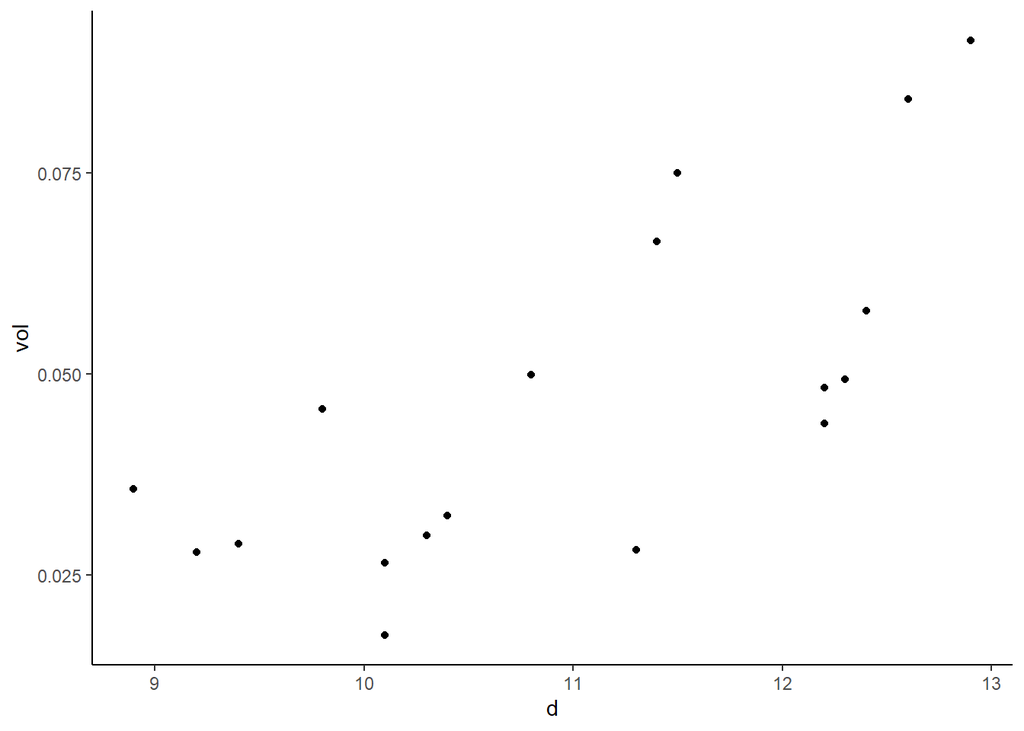

**fig.1** volumen en funcion del diametro

```r
ggplot(datos2, mapping = aes(x = d, y = vol)) +
  geom_point() + theme_classic()
```

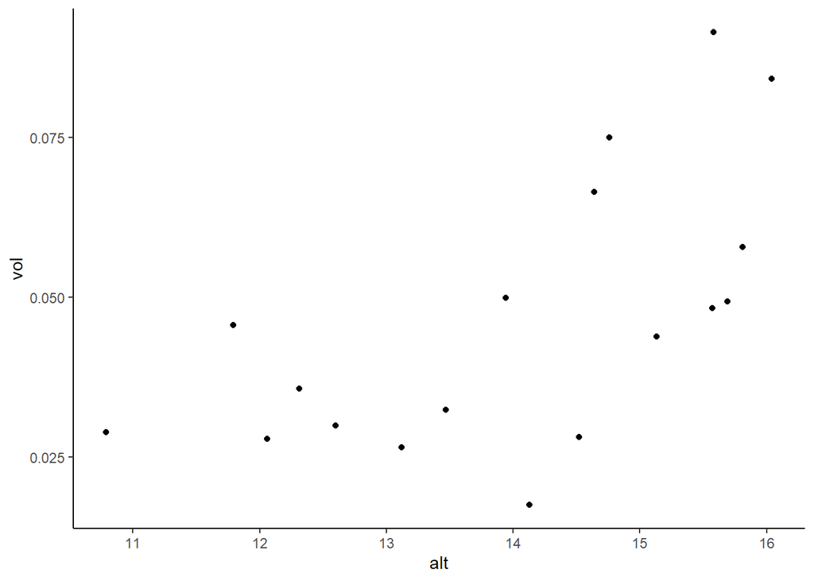

**fig.2** volumen en funcion de la alt

```r
ggplot(datos2, mapping = aes(x = alt, y = vol)) +
  geom_point() + theme_classic()
```

Mediante la regresión lineal se crearon dos modelos: `m1=lm(vol~d) y m2=lm(vol~d^2*alt)`con el `anova` se pudo observar que ambos modelos eran significativos.

Para escoger un mejor modelo entre ellos dos se compara el AIC de cada una y el RSE, así como el sesgo e incertidumbre, que se halla con la fórmula:

$$E\%= 100*\frac{Estimado-Observado}{Observado}$$

El resumen de los modelos se presenta en la siguiente tabla:

```r
mod1<-lm(vol~d,data=datos2)
summary(mod1)
anova(mod1)
summary(mod1)
AIC(mod1)
shapiro.test(residuals(mod1))

predm1=predict(mod1)
error1=100*(predm1-datos3$vol)/datos3$vol
mean(error1)
sd(error1)
```

[output not shown]

| $Modelo$ | $F$ | $R^2$ | $shapiro.test$ | $RSE$ | $AIC$ | $\%Error$ |
| --- | --- | --- | --- | --- | --- | --- |
| $vol= -0.085+.012*dap$ | $17.39^{***}$ | $0.5208$ | $p-valvue= 0.2021$ | $0.01511$ | $-95.95688$ | $9.9 \pm 39.2$ |
| $vol= -2.84e^{-4}+2.678e^{-5}*(dap^2*alt)$ | $17.33^{***}$ | $0.52$ | $p-valvue= 0.2552$ | $0.01513$ | $-95.926993$ | $10.21 \pm 40.38$ |

De los modelos planteados no se puede decir a ciencia cierta cuál es el mejor modelo, puesto que tanto el error estándar de los residuales con el AIC son muy similares y un criterio para escoger es la diferencia entre AIC mayores a 4 por lo que se podría decir que estos modelos son estadísticamente indiferenciables. Teniendo en cuanta eso, se evalúa el criterio del error, mostrando que el modelo 1 tiene un menor sesgo e incertidumbre que el modelo 2, por lo que se podría decir que el primer modelo es más adecuado.

## 4.2

*Haga una prueba teórica de bondad de ajuste al primer modelo*

La prueba de bondad de ajuste permite establecer si el modelo se ajusta bien a los datos, para este caso, se utilizó el criterio de la suma de cuadrados de los residuales $(SSR)$ es bien sabido que si esta da como resultado $0$ la regresión se ajusta completamente a los datos, haciendo una análisis se encuentra este valor, para este caso fue de $0.0036546$ no es cero pero si es un valor pequeño, por lo cual el modelo ajustado es bueno. Para comprobar esto se miró el $R^2$ ajustado, el cual fue de: $0.4908 $ es un número positivo por lo cual es una asociación directa pero no es tan cercana a $1$, sin embargo, tampoco es cercana a $0$ lo que indicaría un ajuste moderado del modelo, apoyado en esto se puede decir que es un modelo aceptable.

## 4.3

*Proponga un buen modelo con base en la última propuesta de 4.1*

El modelo propuesto de `vol` en función de `dap` y `alt` fue el modelo exponencial $vol=b_0*dap^{b_1}*alt^{b_2}$. En la siguiente tabla se presentan los resultados de algunas pruebas de analisis para el modelo:

| $modelo$ | $AIC$ | $RSE$ | $shapiro.test$ | $\%Error$ |
| --- | --- | --- | --- | --- |
| $vol=0.0001*dap^{4.272}*alt^{-1.686}$ | $16.21643$ | $0.0148$ | $p-valvue= 0.4444$ | $10.65 \pm 34.34$ |

Como este es un modelo exponencial, que inicialmente se planteó como logarítmico, no se puede comparar con los dos modelos anteriores bajo el criterio del `AIC`, puesto que la variable dependiente está en distinta escala; sin embargo, se puede comparar el `RSE` y el `error`.

[figure not shown]

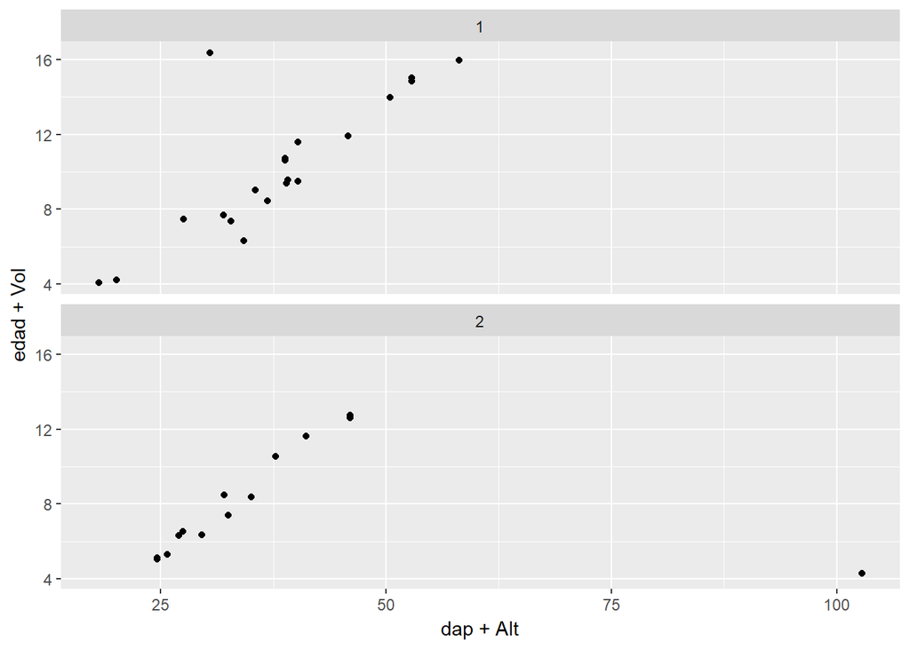

```r
ggplot(datos, mapping = aes(x = dap+Alt, y = edad+Vol)) +
  geom_point() + facet_wrap(~ps, nrow = 2)
```

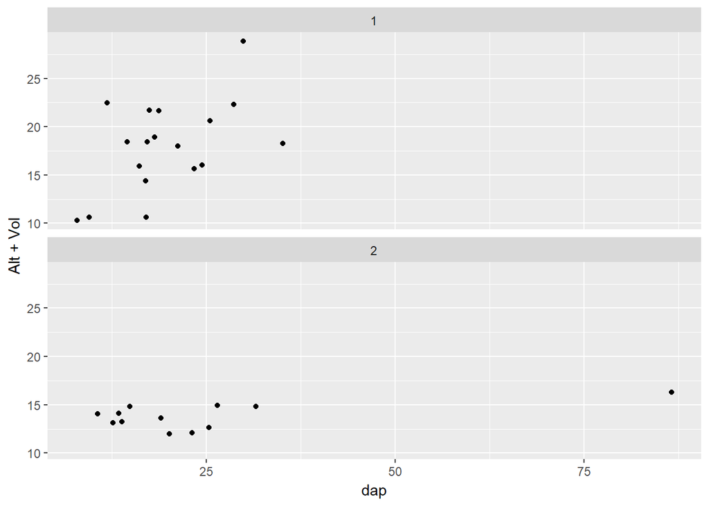

```r
ggplot(datos, mapping = aes(x = dap, y = Alt+Vol)) +
  geom_point() + facet_wrap(~ps, nrow = 2)
```

[figure not shown]

```r
pairs(dap ~ Alt+Vol+edad, data = datos)
```